# CDFS-SWIRE Master List Creation

## Preparation of VIDEO/VISTA/VIRCAM data

The catalogue comes from `dmu0_VISTA_VIDEO-private`.

There is an old public version of the catalogue but we are using the newer private version in the hope that it will be public by the time we publish the masterlist.

In the catalogue, we keep:

- The identifier (it's unique in the catalogue);
- The position (degrees);
- The stellarity;
- The magnitude for each band in apertude 3, which is 2 arcsec (rs548 presumes same for private catalogue).
- The “auto” magnitude is provided, we presume this is standard Sextractor units etc.

Yannick said the dates of observation for VIDEO are from 2009/11 to 2016/12. There is a paper from 2012 (Jarvis et al). So will use 2012.

```python
from herschelhelp_internal import git_version
print("This notebook was run with herschelhelp_internal version: \n{}".format(git_version()))
```

```
This notebook was run with herschelhelp_internal version:
56042ea (Thu Aug 3 18:51:31 2017 +0100)
```

```python
%matplotlib inline
#%config InlineBackend.figure_format = 'svg'

import matplotlib.pyplot as plt
plt.rc('figure', figsize=(10, 6))

from collections import OrderedDict
import os

from astropy import units as u
from astropy.coordinates import SkyCoord
from astropy.table import Column, Table
import numpy as np

from herschelhelp_internal.flagging import  gaia_flag_column
from herschelhelp_internal.masterlist import nb_astcor_diag_plot, remove_duplicates
from herschelhelp_internal.utils import astrometric_correction, mag_to_flux
```

```python
import locale
locale.setlocale(locale.LC_ALL, 'en_GB')
```

```
'en_GB'
```

```python
import logging
logger = logging.getLogger()
logger.setLevel(logging.INFO)
```

```python
OUT_DIR =  os.environ.get('TMP_DIR', "./data_tmp")
try:
    os.makedirs(OUT_DIR)
except FileExistsError:
    pass

RA_COL = "video_ra"
DEC_COL = "video_dec"
```

## I - Column selection

```python
imported_columns = OrderedDict({
        'ID':              'video_id',
        'ALPHA_J2000':     'video_ra',
        'DELTA_J2000':     'video_dec',
        'J_CLASS_STAR':    'video_stellarity',
        'Z_MAG_APER_3':    'm_ap_video_z',
        'Z_MAGERR_APER_3': 'merr_ap_video_z',
        'Z_MAG_AUTO':      'm_video_z',
        'Z_MAGERR_AUTO':   'merr_video_z',
        'Z_FLUX_APER_3':   'f_ap_video_z',
        'Z_FLUXERR_APER_3':'ferr_ap_video_z',
        'Z_FLUX_AUTO':     'f_video_z',
        'Z_FLUXERR_AUTO':  'ferr_video_z',
        'Y_MAG_APER_3':    'm_ap_video_y',
        'Y_MAGERR_APER_3': 'merr_ap_video_y',
        'Y_MAG_AUTO':      'm_video_y',
        'Y_MAGERR_AUTO':   'merr_video_y',
        'Y_FLUX_APER_3':   'f_ap_video_y',
        'Y_FLUXERR_APER_3':'ferr_ap_video_y',
        'Y_FLUX_AUTO':     'f_video_y',
        'Y_FLUXERR_AUTO':  'ferr_video_y',
        'J_MAG_APER_3':    'm_ap_video_j',
        'J_MAGERR_APER_3': 'merr_ap_video_j',
        'J_MAG_AUTO':      'm_video_j',
        'J_MAGERR_AUTO':   'merr_video_j',
        'J_FLUX_APER_3':   'f_ap_video_j',
        'J_FLUXERR_APER_3':'ferr_ap_video_j',
        'J_FLUX_AUTO':     'f_video_j',
        'J_FLUXERR_AUTO':  'ferr_video_j',
        'H_MAG_APER_3':    'm_ap_video_h',
        'H_MAGERR_APER_3': 'merr_ap_video_h',
        'H_MAG_AUTO':      'm_video_h',
        'H_MAGERR_AUTO':   'merr_video_h',
        'H_FLUX_APER_3':   'f_ap_video_h',
        'H_FLUXERR_APER_3':'ferr_ap_video_h',
        'H_FLUX_AUTO':     'f_video_h',
        'H_FLUXERR_AUTO':  'ferr_video_h',
        'K_MAG_APER_3':    'm_ap_video_k',
        'K_MAGERR_APER_3': 'merr_ap_video_k',
        'K_MAG_AUTO':      'm_video_k',
        'K_MAGERR_AUTO':   'merr_video_k',
        'K_FLUX_APER_3':   'f_ap_video_k',
        'K_FLUXERR_APER_3':'ferr_ap_video_k',
        'K_FLUX_AUTO':     'f_video_k',
        'K_FLUXERR_AUTO':  'ferr_video_k'
})


catalogue = Table.read("../../dmu0/dmu0_VISTA-VIDEO-private/data/VIDEO-all_2016-04-14_fullcat_errfix_CDFS-SWIRE.fits"
                      )[list(imported_columns)]
for column in imported_columns:
    catalogue[column].name = imported_columns[column]


epoch = 2012

# Clean table metadata
catalogue.meta = None
```

```python
#Replace 99.0 with NaN values
for col in catalogue.colnames:
    catalogue[col].unit = None
    if col.startswith('m'): # | col.endswith('ra') | col.endswith('dec'):
        catalogue[col][np.where(catalogue[col] > 90.0)] = np.nan
    #Remove negative fluxes. These could contain upper limits but we do not want this information in the masterlist.
    if col.startswith('f'): # | col.endswith('ra') | col.endswith('dec'):
        catalogue[col][np.where(catalogue[col] < 0.0)] = np.nan

# Adding band-flag columns
for col in catalogue.colnames:
    if col.startswith('m_'):

        #errcol = "merr{}".format(col[1:])
        #flux, error = utils.mag_to_flux(np.array(video[col]), np.array(video[errcol]))

        # Fluxes are added in µJy
        #video.add_column(Column(flux * 1.e6, name="f{}".format(col[1:])))
        #video.add_column(Column(error * 1.e6, name="f{}".format(errcol[1:])))

        # Band-flag column
        if "ap" not in col:
            catalogue.add_column(Column(np.zeros(len(catalogue), dtype=bool), name="flag{}".format(col[1:])))

# TODO: Set to True the flag columns for fluxes that should not be used for SED fitting.
```

```python
catalogue[:10].show_in_notebook()
```

<Table length=10>

| idx | video_id | video_ra | video_dec | video_stellarity | m_ap_video_z | merr_ap_video_z | m_video_z | merr_video_z | f_ap_video_z | ferr_ap_video_z | f_video_z | ferr_video_z | m_ap_video_y | merr_ap_video_y | m_video_y | merr_video_y | f_ap_video_y | ferr_ap_video_y | f_video_y | ferr_video_y | m_ap_video_j | merr_ap_video_j | m_video_j | merr_video_j | f_ap_video_j | ferr_ap_video_j | f_video_j | ferr_video_j | m_ap_video_h | … |
| --- | --- | --- | --- | --- | --- | --- | --- | --- | --- | --- | --- | --- | --- | --- | --- | --- | --- | --- | --- | --- | --- | --- | --- | --- | --- | --- | --- | --- | --- | --- |
| 0 | 1000001 | 51.80079195 | -29.2354211328 | 0.346685 | nan | nan | nan | nan | nan | 41.8464 | nan | 83.5452 | 22.6216 | 0.258056 | 26.0647 | 5.09141 | 894.007 | 212.493 | 37.5068 | 175.889 | nan | nan | 23.9925 | 1.0032 | nan | 431.997 | 252.926 | 233.707 | 23.2518 | … |
| 1 | 1000002 | 51.6895170351 | -29.2340035071 | 0.966597 | nan | nan | nan | nan | nan | 41.8464 | nan | 83.5452 | 20.2414 | 0.0337333 | 20.0631 | 0.0339792 | 8006.65 | 248.771 | 9435.78 | 295.312 | 19.6768 | 0.0407417 | 19.5576 | 0.0403623 | 13467.9 | 505.393 | 15029.9 | 558.756 | 19.5169 | … |
| 2 | 1000003 | 51.7010484071 | -29.2341161444 | 0.612804 | nan | nan | nan | nan | nan | 41.8464 | nan | 83.5452 | 23.7939 | 0.874631 | nan | nan | 303.697 | 244.656 | nan | 148.147 | nan | nan | 24.4364 | 1.7206 | nan | 518.645 | 168.049 | 266.321 | 25.0755 | … |
| 3 | 1000004 | 51.8898615783 | -29.2361107276 | 0.664363 | 27.6763 | 5.34425 | 27.0441 | 5.96015 | 8.50122 | 41.8464 | 15.2186 | 83.5452 | 21.5108 | 0.0935531 | 20.9963 | 0.0834751 | 2487.02 | 214.303 | 3994.83 | 307.147 | 21.0316 | 0.103648 | 20.678 | 0.0977747 | 3866.8 | 369.149 | 5355.72 | 482.319 | 20.6607 | … |
| 4 | 1000005 | 51.853580029 | -29.2354194293 | 0.654366 | 27.5283 | 4.6632 | 29.1158 | 40.1736 | 9.7428 | 41.8464 | 2.25783 | 83.5452 | 22.7826 | 0.159906 | 23.5619 | 0.370563 | 770.824 | 113.53 | 376.061 | 128.354 | 22.3107 | 0.303907 | 22.5141 | 0.228907 | 1190.52 | 333.249 | 987.064 | 208.111 | 22.2332 | … |
| 5 | 1000006 | 51.8860150497 | -29.2356122466 | 0.775928 | 27.8467 | 6.25221 | 27.9764 | 14.0661 | 7.26665 | 41.8464 | 6.44847 | 83.5452 | 21.8208 | 0.0629794 | 22.0858 | 0.109434 | 1869.33 | 108.436 | 1464.51 | 147.617 | 21.8143 | 0.154482 | 21.9337 | 0.184579 | 1880.5 | 267.572 | 1684.69 | 286.412 | 22.1325 | … |
| 6 | 1000007 | 51.7777651536 | -29.2344681682 | 0.650606 | 28.1389 | 8.1835 | 30.3054 | nan | 5.55173 | 41.8464 | 0.754824 | 83.5452 | 23.2437 | 0.23421 | 26.3213 | 4.55147 | 504.103 | 108.746 | 29.6121 | 124.14 | 21.9291 | 0.196215 | 23.894 | 0.661324 | 1691.78 | 305.749 | 276.956 | 168.7 | 23.1299 | … |
| 7 | 1000008 | 51.9136213696 | -29.235773692 | 0.454603 | nan | nan | nan | nan | nan | 41.8464 | nan | 83.5452 | nan | nan | 24.2839 | 0.986324 | nan | 284.04 | 193.391 | 175.69 | 23.6014 | 2.32812 | 26.283 | 9.33287 | 362.603 | 777.546 | 30.6757 | 263.694 | 24.1508 | … |
| 8 | 1000009 | 51.831886149 | -29.2349764138 | 0.650206 | 25.8757 | 1.01778 | 26.1659 | 2.6545 | 44.6391 | 41.8464 | 34.1703 | 83.5452 | 23.2525 | 0.228168 | 23.2969 | 0.319984 | 500.019 | 105.083 | 479.994 | 141.467 | 23.6731 | 0.797035 | 23.0868 | 0.458816 | 339.443 | 249.192 | 582.461 | 246.148 | 21.4022 | … |
| 9 | 1000010 | 51.9471404014 | -29.2360320189 | 0.503456 | nan | nan | nan | nan | nan | 41.8464 | nan | 83.5452 | nan | nan | nan | nan | nan | 283.11 | nan | 182.709 | nan | nan | nan | nan | nan | 543.505 | nan | 294.063 | 21.4683 | … |

## II - Removal of duplicated sources

We remove duplicated objects from the input catalogues.

```python
SORT_COLS = ['merr_ap_video_z', 'merr_ap_video_y', 'merr_ap_video_j', 'merr_ap_video_h', 'merr_ap_video_k']
FLAG_NAME = 'video_flag_cleaned'

nb_orig_sources = len(catalogue)

catalogue = remove_duplicates(catalogue, RA_COL, DEC_COL, sort_col=SORT_COLS,flag_name=FLAG_NAME)

nb_sources = len(catalogue)

print("The initial catalogue had {} sources.".format(nb_orig_sources))
print("The cleaned catalogue has {} sources ({} removed).".format(nb_sources, nb_orig_sources - nb_sources))
print("The cleaned catalogue has {} sources flagged as having been cleaned".format(np.sum(catalogue[FLAG_NAME])))
```

```
The initial catalogue had 900972 sources.
The cleaned catalogue has 899342 sources (1630 removed).
The cleaned catalogue has 1622 sources flagged as having been cleaned
```

## III - Astrometry correction

We match the astrometry to the Gaia one. We limit the Gaia catalogue to sources with a g band flux between the 30th and the 70th percentile. Some quick tests show that this give the lower dispersion in the results.

```python
gaia = Table.read("../../dmu0/dmu0_GAIA/data/GAIA_CDFS-SWIRE.fits")
gaia_coords = SkyCoord(gaia['ra'], gaia['dec'])
```

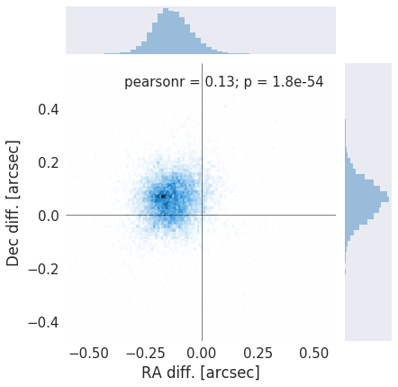

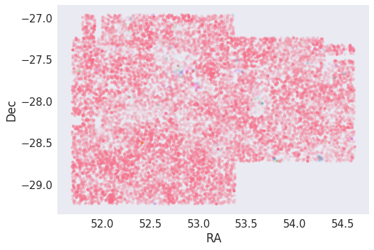

```python
nb_astcor_diag_plot(catalogue[RA_COL], catalogue[DEC_COL],
                    gaia_coords.ra, gaia_coords.dec)
```

```python
delta_ra, delta_dec =  astrometric_correction(
    SkyCoord(catalogue[RA_COL], catalogue[DEC_COL]),
    gaia_coords
)

print("RA correction: {}".format(delta_ra))
print("Dec correction: {}".format(delta_dec))
```

```
RA correction: 0.1351182450662236 arcsec
Dec correction: -0.05909179080134663 arcsec
```

```python
catalogue[RA_COL] +=  delta_ra.to(u.deg)
catalogue[DEC_COL] += delta_dec.to(u.deg)
```

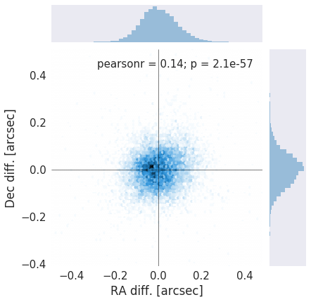

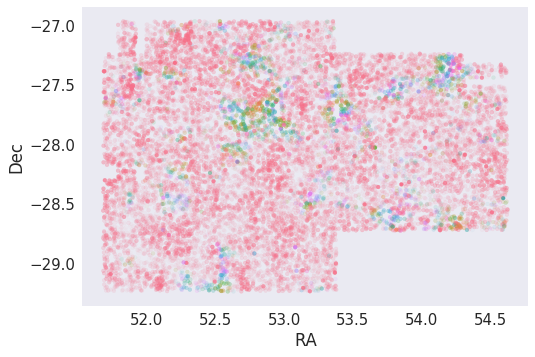

```python
nb_astcor_diag_plot(catalogue[RA_COL], catalogue[DEC_COL],
                    gaia_coords.ra, gaia_coords.dec)
```

## IV - Flagging Gaia objects

```python
catalogue.add_column(
    gaia_flag_column(SkyCoord(catalogue[RA_COL], catalogue[DEC_COL]), epoch, gaia)
)
```

```python
GAIA_FLAG_NAME = "video_flag_gaia"

catalogue['flag_gaia'].name = GAIA_FLAG_NAME
print("{} sources flagged.".format(np.sum(catalogue[GAIA_FLAG_NAME] > 0)))
```

```
13679 sources flagged.
```

## IV - Flagging objects near bright stars

```python
#This section may be superseeded by merely using multiband detection as evidence of good data
#starmask.flag_artefacts
```

## V - Saving to disk

```python
catalogue.write("{}/VISTA-VIDEO.fits".format(OUT_DIR), overwrite=True)
```